# Causality: Worker Injury Benefits and Time Out of Work

Quantitative Methods for Humanities

CUNEF Universidad

# Introduction

In July 1980, Kentucky raised the cap on weekly worker injury benefits from $131 to $217 — a **66% increase**. Only **high-earning workers** were eligible for the new cap. This policy change creates a natural experiment where we can explore whether more generous compensation discourages injured workers from returning to work quickly.

In this document, we apply both **Before-and-After** and **Difference-in-Differences** designs to estimate the causal effect of this policy using the dataset `injury.RData`.

# Q1. Treatment vs Outcome

- **Treatment:** Being a high earner *after* the policy change. Variable `highearn` equals 1.
- **Outcome:** `ldurat`, the log of weeks out of work.

# Q2. Simple Comparison After Policy?

Simply comparing high earners vs. low earners *after* the policy ignores that these groups may have differed even before July 1980. This would confound pre-existing differences with the policy’s effect. A **Difference-in-Means After** estimator would be **biased**. This is typical in observational studies, where randomization is not guaranteed and, thus, the presence of confounders between the treatment and control group may significantly differ.

# Q3. Before-and-After Design

If we insist on a before-after comparison:

- **Treated group:** High earners after the treatment (law) was implemented.
- **Control group:** High earners before the treatment (law) was implemented.

We must compare their average out-of-work time (`ldurat`) before vs. after the policy.

# Q4. Load and Inspect the Data

```r
load("injury.RData")
summary(injury)
```

```
##      durat            afchnge          highearn           male
##  Min.   :  0.250   Min.   :0.0000   Min.   :0.0000   Min.   :0.0000
##  1st Qu.:  2.000   1st Qu.:0.0000   1st Qu.:0.0000   1st Qu.:1.0000
##  Median :  4.000   Median :0.0000   Median :0.0000   Median :1.0000
##  Mean   :  9.922   Mean   :0.4733   Mean   :0.3989   Mean   :0.7806
##  3rd Qu.:  8.000   3rd Qu.:1.0000   3rd Qu.:1.0000   3rd Qu.:1.0000
##  Max.   :182.000   Max.   :1.0000   Max.   :1.0000   Max.   :1.0000
##                                                      NA's   :16
##     married            hosp            indust         injtype
##  Min.   :0.0000   Min.   :0.0000   Min.   :1.000   Min.   :1.000
##  1st Qu.:0.0000   1st Qu.:0.0000   1st Qu.:1.000   1st Qu.:3.000
##  Median :1.0000   Median :0.0000   Median :3.000   Median :5.000
##  Mean   :0.6923   Mean   :0.2621   Mean   :2.292   Mean   :4.451
##  3rd Qu.:1.0000   3rd Qu.:1.0000   3rd Qu.:3.000   3rd Qu.:6.000
##  Max.   :1.0000   Max.   :1.0000   Max.   :3.000   Max.   :8.000
##  NA's   :297                       NA's   :25
##       age           prewage            totmed              injdes
##  Min.   :12.00   Min.   :  81.78   Min.   :      0.0   Min.   :1007
##  1st Qu.:24.00   1st Qu.: 184.63   1st Qu.:    148.9   1st Qu.:3610
##  Median :32.00   Median : 263.85   Median :    328.6   Median :4252
##  Mean   :34.71   Mean   : 329.73   Mean   :   1714.4   Mean   :4385
##  3rd Qu.:43.00   3rd Qu.: 449.67   3rd Qu.:   1264.7   3rd Qu.:5310
##  Max.   :98.00   Max.   :1583.10   Max.   :2323376.5   Max.   :9052
##  NA's   :4
##     benefit             ky               mi             ldurat
##  Min.   : 14.87   Min.   :0.0000   Min.   :0.0000   Min.   :-1.3863
##  1st Qu.:118.95   1st Qu.:1.0000   1st Qu.:0.0000   1st Qu.: 0.6931
##  Median :149.93   Median :1.0000   Median :0.0000   Median : 1.3863
##  Mean   :162.92   Mean   :0.7869   Mean   :0.2131   Mean   : 1.3327
##  3rd Qu.:193.32   3rd Qu.:1.0000   3rd Qu.:0.0000   3rd Qu.: 2.0794
##  Max.   :742.22   Max.   :1.0000   Max.   :1.0000   Max.   : 5.2040
##
##      afhigh         lprewage          lage          ltotmed
##  Min.   :0.000   Min.   :4.404   Min.   :2.485   Min.   : 0.000
##  1st Qu.:0.000   1st Qu.:5.218   1st Qu.:3.178   1st Qu.: 5.003
##  Median :0.000   Median :5.575   Median :3.466   Median : 5.795
##  Mean   :0.193   Mean   :5.654   Mean   :3.483   Mean   : 5.927
##  3rd Qu.:0.000   3rd Qu.:6.109   3rd Qu.:3.761   3rd Qu.: 7.143
##  Max.   :1.000   Max.   :7.367   Max.   :4.585   Max.   :14.659
##                                  NA's   :4
```

[output cut: 9 more lines]

```
##  Min.   :0.0000   Min.   :0.0000   Min.   :0.00000   Min.   :0.0000
##  1st Qu.:0.0000   1st Qu.:0.0000   1st Qu.:0.00000   1st Qu.:0.0000
##  Median :0.0000   Median :0.0000   Median :0.00000   Median :0.0000
##  Mean   :0.2618   Mean   :0.2316   Mean   :0.01077   Mean   :0.2808
##  3rd Qu.:1.0000   3rd Qu.:0.0000   3rd Qu.:0.00000   3rd Qu.:1.0000
##  Max.   :1.0000   Max.   :1.0000   Max.   :1.00000   Max.   :1.0000
##                                                      NA's   :25
##     construc         highlpre
##  Min.   :0.0000   Min.   :0.000
##  1st Qu.:0.0000   1st Qu.:0.000
##  Median :0.0000   Median :0.000
##  Mean   :0.1458   Mean   :2.484
##  3rd Qu.:0.0000   3rd Qu.:6.109
##  Max.   :1.0000   Max.   :7.367
##  NA's   :25
```

```r
table(injury$highearn)
```

```
##
##    0    1
## 4298 2852
```

# Q5. Before-and-After Estimator (BA)

```r
# Compute means for high earners before and after
high_earners <- subset(injury, highearn == 1)

mean_before <- mean(high_earners$ldurat[high_earners$afchnge == 0], na.rm = TRUE)
mean_after <- mean(high_earners$ldurat[high_earners$afchnge == 1], na.rm = TRUE)

ba_estimate <- mean_after - mean_before
ba_estimate
```

```
## [1] 0.2119848
```

```r
# Compute the overall variance as a benchmark for the difference
sd(high_earners$ldurat)
```

```
## [1] 1.32797
```

**Interpretation:** This difference might reflect the policy effect, but it may also capture general trends over time.

Besides, the difference is somehow significant, since it accounts for about 16% of the standard deviation.

Formally, a hypothesis test determines wheather this difference is significant or not by comparing the p-value with a significant level.

```r
# Hypothesis test: high earners before vs after
t.test(ldurat ~ afchnge, data = high_earners)
```

```
##
##  Welch Two Sample t-test
##
## data:  ldurat by afchnge
## t = -4.2723, df = 2835.9, p-value = 1.998e-05
## alternative hypothesis: true difference in means between group 0 and group 1 is not equal to 0
## 95 percent confidence interval:
##  -0.3092763 -0.1146934
## sample estimates:
## mean in group 0 mean in group 1
##        1.414531        1.626516
```

**Note:** Recall that, if you were to report the difference, you may want to transform back to the original scale (exponentiate to remove logarithmic scale)

# Q6. Limitations of BA — Why DiD?

- **Problem:** BA can’t separate **policy effects** from **time trends** (e.g., recession, economic changes).
- **Solution:** Estimate the time trend by using the group of low earners before and after the policy.
- DiD compares the **change** in outcomes *within each group* and then **differences the changes**.

# Q7. Why Do We Need Parallel Trends?

DiD assumes that, **in the absence of the policy**, the treated and control groups would have **followed similar trends** over time. This lets us state that **any difference observed after the policy is due to the policy itself**.

# Q8. Plain Explanation of DiD Terms

$$\widehat{\mathrm{SATE}}_{\mathrm{DiD}} =
(\overline{Y}_T^{\mathrm{after}} - \overline{Y}_T^{\mathrm{before}})
- (\overline{Y}_C^{\mathrm{after}} - \overline{Y}_C^{\mathrm{before}})$$

- The **first term** measures how outcomes changed for the **treated** group before and after the policy was implemented.
- The **second term** captures change in the **control** group (i.e., the trend we’d expect without treatment).
- The **difference** isolates the causal effect.

# Q9. Compute the DiD Estimator

```r
# Split into groups
treated_before <- subset(injury, highearn == 1 & afchnge == 0)
treated_after  <- subset(injury, highearn == 1 & afchnge == 1)
control_before <- subset(injury, highearn == 0 & afchnge == 0)
control_after  <- subset(injury, highearn == 0 & afchnge == 1)

# Compute mean values for each group
mean_tb <- mean(treated_before$ldurat, na.rm = TRUE)
mean_ta <- mean(treated_after$ldurat, na.rm = TRUE)
mean_cb <- mean(control_before$ldurat, na.rm = TRUE)
mean_ca <- mean(control_after$ldurat, na.rm = TRUE)

# Coimpute differences of treatment and control groups
treat_diff <- (mean_tb - mean_ta)
control_diff <- (mean_cb - mean_ca)

# DiD estimator
did_estimate <- treat_diff - control_diff
did_estimate
```

```
## [1] -0.1883498
```

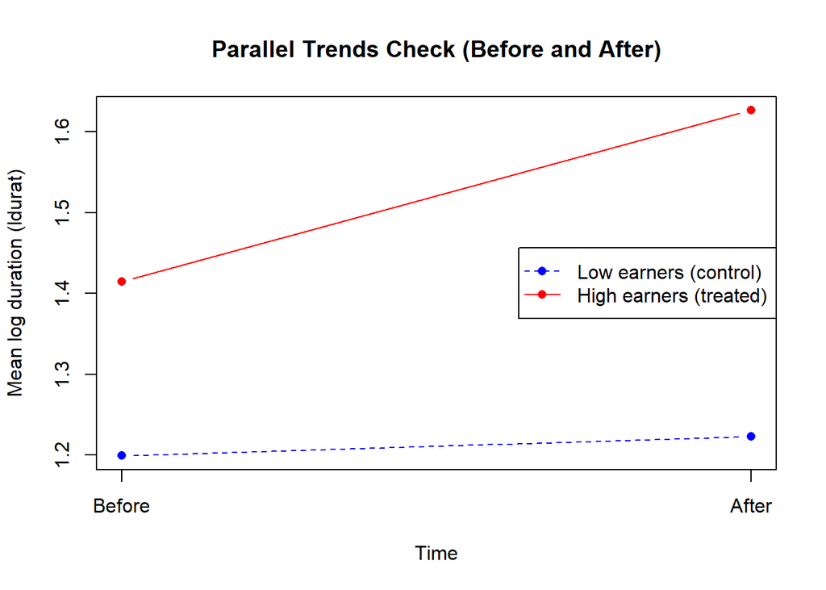

```r
# Plotting
plot(0:1, c(mean_cb, mean_ca), type = "b", pch = 16, col = "blue", lty = 2,
     ylim = range(mean_tb, mean_ta, mean_cb, mean_ca), xaxt = "n", xlab = "Time", ylab = "Mean log duration (ldurat)",
     main = "Parallel Trends Check (Before and After)")
axis(1, at = 0:1, labels = c("Before", "After"))

lines(0:1, c(mean_tb, mean_ta), type = "b", pch = 16, col = "red", lty = 1)

legend("right", legend = c("Low earners (control)", "High earners (treated)"),
       col = c("blue", "red"), lty = c(2, 1), pch = 16)
```

# Q10. Potential Threats to Validity

Even DiD has assumptions. Some threats include:

- A recession or industry shock that disproportionately hits high earners.
- Policy spillovers: e.g., firms reacting by delaying rehiring high earners.
- Anticipation effects: if people knew the policy was coming, they might delay filing.

# Summary

This example illustrates how quasi-experimental designs like DiD can help answer causal questions when **randomization is not feasible**. However, we must always be cautious about the assumptions we’re making and validate them with data where possible.

# Exercise

- Perform the same causal inference analysis but controling for gender (`male` variable)